# Mixtures Workshop: Grouped Lasso

Lizzy Gibson

July 18, 2018

# Data Import and Cleaning

First, load the dataset; clean up names as needed; and convert factors to, well, factors.

```r
study_pop = read_csv("./Data/studypop.csv") %>%
  clean_names(case = c("old_janitor")) %>%
  mutate(bmi_cat3 = as.factor(bmi_cat3),
         edu_cat = as.factor(edu_cat),
         race_cat = as.factor(race_cat),
         male = as.factor(male))
```

Quick data descriptions; because of the length of the output, we don’t execute this command here, but encourage you to!

```r
describe(study_pop)
```

Next we remove missing values and reorder predictors (environmental variables first, confounders second). In keeping with standard practice, we’ll ln-transform the environmental exposures and the outcome. This is the dataset we’ll use to illustrate variable selection methods.

```r
data_lasso = study_pop %>%
  mutate_at(vars(contains("la")), log) %>%
  mutate(log_telomean = log(telomean)) %>%
  dplyr::select(log_telomean, lbx074la:lbx187la, lbxd03la:lbx194la, everything(), -seqn, -telomean) %>%
  na.omit(log_telomean)

names(data_lasso)
```

```
##  [1] "log_telomean" "lbx074la"     "lbx099la"     "lbx118la"
##  [5] "lbx138la"     "lbx153la"     "lbx170la"     "lbx180la"
##  [9] "lbx187la"     "lbxd03la"     "lbxd05la"     "lbxd07la"
## [13] "lbxf03la"     "lbxf04la"     "lbxf05la"     "lbxf08la"
## [17] "lbxpcbla"     "lbxhxcla"     "lbx194la"     "lbxwbcsi"
## [21] "lbxlypct"     "lbxmopct"     "lbxnepct"     "lbxeopct"
## [25] "lbxbapct"     "bmi_cat3"     "edu_cat"      "race_cat"
## [29] "male"         "ln_lbxcot"    "age_cent"     "age_sq"
```

```r
dim(data_lasso)
```

```
## [1] 1003   32
```

Model fitting methods aren’t “tidy-compliant” yet, so we’ll focus on creating the relevant matrices and vectors.

```r
# Create a matrix of predictors as x
x = model.matrix(log_telomean ~ ., data_lasso)[,-1]

# Extract outcome vector
y = data_lasso$log_telomean
```

Let’s take a quick look at our design matrix.

```r
dim(x)
```

```
## [1] 1003   36
```

```r
colnames(x)
```

```
##  [1] "lbx074la"  "lbx099la"  "lbx118la"  "lbx138la"  "lbx153la"
##  [6] "lbx170la"  "lbx180la"  "lbx187la"  "lbxd03la"  "lbxd05la"
## [11] "lbxd07la"  "lbxf03la"  "lbxf04la"  "lbxf05la"  "lbxf08la"
## [16] "lbxpcbla"  "lbxhxcla"  "lbx194la"  "lbxwbcsi"  "lbxlypct"
## [21] "lbxmopct"  "lbxnepct"  "lbxeopct"  "lbxbapct"  "bmi_cat32"
## [26] "bmi_cat33" "edu_cat2"  "edu_cat3"  "edu_cat4"  "race_cat2"
## [31] "race_cat3" "race_cat4" "male1"     "ln_lbxcot" "age_cent"
## [36] "age_sq"
```

```r
#View(x)
```

It’s helpful to note that chemical exposures appear in columns 1 to 18, and more traditional confounders appear in columns 19 to 36.

# Group definitions

Create grouping variable two ways. If there are coefficients to be included in the model without being penalized, assign them to group 0 (or “0”). This includes all covariates we want to keep in the model. Group must be a FACTOR.

First, 3 groups = 8 non-Dioxin-like PCBs, 2 non-ortho PCBs, and TEQ (3 dioxins, 4 furans, 1 mono-ortho (Dioxin-like) PCBs).

```r
group3 <- vector()
group3[grepl("lbx1|0",colnames(x))] <- "Non-Dioxin-like PCB"
group3[grepl("lbxd", colnames(x))] <- "TEQ"
group3[grepl("lbxf", colnames(x))] <- "TEQ"
group3[grepl("lbxh|p", colnames(x))] <- "Non-Ortho PCB"
group3[grepl("lbx118la", colnames(x))] <- "TEQ"
group3[grepl("pct", colnames(x))] <- "0"
group3[grepl("bcsi", colnames(x))] <- "0"
group3[grepl("bmi", colnames(x))] <- "0"
group3[grepl("edu", colnames(x))] <- "0"
group3[grepl("race", colnames(x))] <- "0"
group3[grepl("male", colnames(x))] <- "0"
group3[grepl("bxcot", colnames(x))] <- "0"
group3[grepl("age", colnames(x))] <- "0"
group3 <- as.factor(group3)

cbind(colnames(x), group3) #bind by columns
```

```
##                   group3
##  [1,] "lbx074la"  "2"
##  [2,] "lbx099la"  "2"
##  [3,] "lbx118la"  "4"
##  [4,] "lbx138la"  "2"
##  [5,] "lbx153la"  "2"
##  [6,] "lbx170la"  "2"
##  [7,] "lbx180la"  "2"
##  [8,] "lbx187la"  "2"
##  [9,] "lbxd03la"  "4"
## [10,] "lbxd05la"  "4"
## [11,] "lbxd07la"  "4"
## [12,] "lbxf03la"  "4"
## [13,] "lbxf04la"  "4"
## [14,] "lbxf05la"  "4"
```

[output cut: 22 more lines]

Second, 4 groups = 8 non-dioxin-like PCBs, 3 non-ortho PCBs, 3 dioxins, and 4 furans.

```r
group4 <- vector()
group4[grepl("lbx1|0",colnames(x))] <- "Non-Dioxin-like PCB"
group4[grepl("lbxd", colnames(x))] <- "Dioxin"
group4[grepl("lbxf", colnames(x))] <- "Furan"
group4[grepl("lbxh|p", colnames(x))] <- "Non-Ortho PCB"
group4[grepl("lbx118la", colnames(x))] <- "Non-Ortho PCB"
group4[grepl("pct", colnames(x))] <- "0"
group4[grepl("bcsi", colnames(x))] <- "0"
group4[grepl("bmi", colnames(x))] <- "0"
group4[grepl("edu", colnames(x))] <- "0"
group4[grepl("race", colnames(x))] <- "0"
group4[grepl("male", colnames(x))] <- "0"
group4[grepl("bxcot", colnames(x))] <- "0"
group4[grepl("age", colnames(x))] <- "0"
group4 <- as.factor(group4)

cbind(colnames(x), group4)
```

```
##                   group4
##  [1,] "lbx074la"  "4"
##  [2,] "lbx099la"  "4"
##  [3,] "lbx118la"  "5"
##  [4,] "lbx138la"  "4"
##  [5,] "lbx153la"  "4"
##  [6,] "lbx170la"  "4"
##  [7,] "lbx180la"  "4"
##  [8,] "lbx187la"  "4"
##  [9,] "lbxd03la"  "2"
## [10,] "lbxd05la"  "2"
## [11,] "lbxd07la"  "2"
## [12,] "lbxf03la"  "3"
## [13,] "lbxf04la"  "3"
## [14,] "lbxf05la"  "3"
```

[output cut: 22 more lines]

# Grouped Variable Selection

The code chunk below fits a three-group model using lasso, MCP, and SCAD penalties.

```r
lasso_3 <- grpreg(x, y, group3, penalty = "grLasso")
MCP_3 <- grpreg(x, y, group3, penalty = "grMCP")
SCAD_3 <- grpreg(x, y, group3, penalty = "grSCAD")
```

Results are illustrated below.

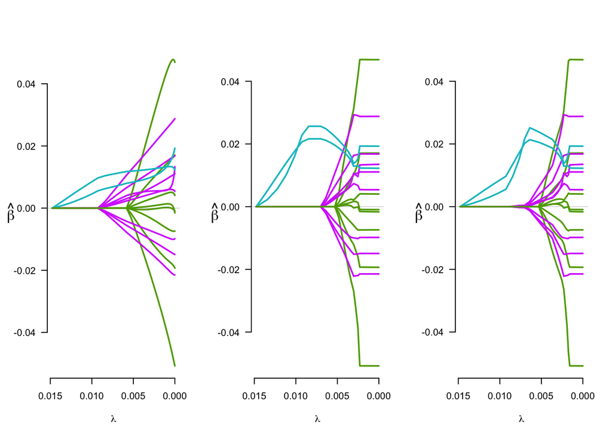

```r
par(mfrow = c(1,3))
plot(lasso_3)
plot(MCP_3)
plot(SCAD_3)
```

We repeat this process for the four-group categorization next.

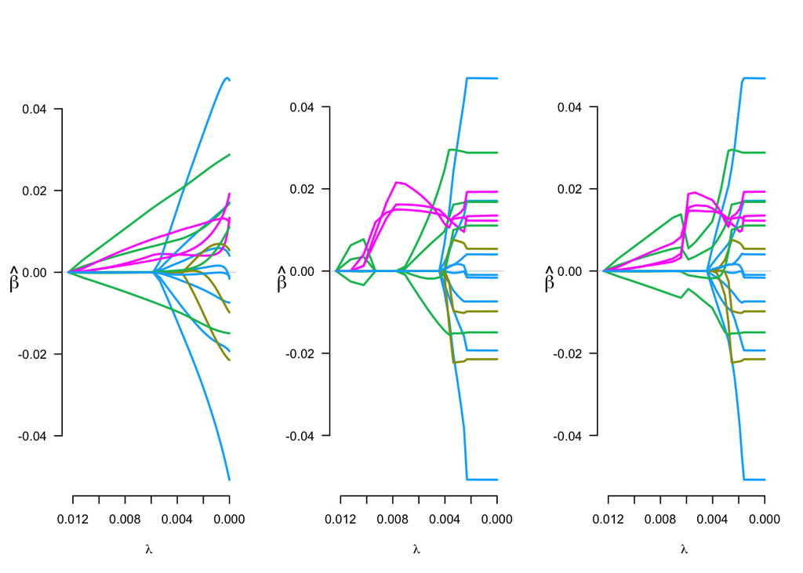

```r
lasso_4 <- grpreg(x, y, group4, penalty = "grLasso")
MCP_4 <- grpreg(x, y, group4, penalty = "grMCP")
SCAD_4 <- grpreg(x, y, group4, penalty = "grSCAD")

par(mfrow = c(1,3))
plot(lasso_4)
plot(MCP_4)
plot(SCAD_4)
```

# Lasso w/ CV

As with `glmnet`, we can use CV to choose the tuning parameters. If not specified in code, ten-fold CV is the default.

We perform this analysis first with the three-group model and the lasso penalty.

```r
cv_lasso_3 <- cv.grpreg(x, y, group3,
                        penalty = "grLasso", seed = 1988)

#Find the lambda that results in the smallest CV error
best_lasso_3 <- cv_lasso_3$lambda.min

#Fit model with cross-validated lambda
fit_lasso_3 <- grpreg(x, y, group3, penalty = "grLasso", lambda = best_lasso_3)

#Look at coefficients from model with best lambda
fit_lasso_3$beta
```

```
##                     0.0058
## (Intercept)  0.18510558267
## lbx074la     0.00000000000
## lbx099la     0.00000000000
## lbx118la     0.00403088058
## lbx138la     0.00000000000
## lbx153la     0.00000000000
## lbx170la     0.00000000000
## lbx180la     0.00000000000
## lbx187la     0.00000000000
## lbxd03la    -0.00422392826
## lbxd05la     0.00230701125
## lbxd07la    -0.00774868322
## lbxf03la     0.01056748621
## lbxf04la     0.00302155107
## lbxf05la    -0.00553011554
## lbxf08la     0.00653974705
## lbxpcbla     0.01176175885
## lbxhxcla     0.00795738879
## lbx194la     0.00000000000
## lbxwbcsi    -0.00632200877
## lbxlypct    -0.00144118871
## lbxmopct    -0.00638864425
## lbxnepct    -0.00056860556
## lbxeopct    -0.00058360299
## lbxbapct     0.01816116021
## bmi_cat32   -0.00407208328
## bmi_cat33   -0.01797071936
## edu_cat2     0.01949098338
## edu_cat3     0.03604538369
## edu_cat4     0.01500729745
## race_cat2   -0.02933858917
## race_cat3    0.01002605361
## race_cat4   -0.03466793695
## male1       -0.04060998165
## ln_lbxcot    0.00343867677
## age_cent    -0.00612739252
## age_sq      -0.00001036405
```

For completeness, we can repeat this with four groups.

```r
#4 group model
cv_lasso_4 <- cv.grpreg(x, y, group4, penalty = "grLasso", seed = 1988)

#Find the lambda that results in the smallest CV error
best_lasso_4 <- cv_lasso_4$lambda.min

#Fit model with cross-validated lambda
fit_lasso_4 <- grpreg(x, y, group4, penalty = "grLasso",
                      lambda = best_lasso_4)

#Look at coefficients from model with best lambda
fit_lasso_4$beta
```

```
##                      0.0059
## (Intercept)  0.118401653759
## lbx074la     0.000000000000
## lbx099la     0.000000000000
## lbx118la     0.004240296100
## lbx138la     0.000000000000
## lbx153la     0.000000000000
## lbx170la     0.000000000000
## lbx180la     0.000000000000
## lbx187la     0.000000000000
## lbxd03la     0.000000000000
## lbxd05la     0.000000000000
## lbxd07la     0.000000000000
## lbxf03la     0.015772614307
## lbxf04la     0.000085315107
## lbxf05la    -0.007248076006
## lbxf08la     0.006364831613
## lbxpcbla     0.008156695818
## lbxhxcla     0.002951331650
## lbx194la     0.000000000000
## lbxwbcsi    -0.006336362398
## lbxlypct    -0.001012349601
## lbxmopct    -0.006152687675
## lbxnepct    -0.000196253224
## lbxeopct     0.000016264214
## lbxbapct     0.018423453513
## bmi_cat32   -0.004909082693
## bmi_cat33   -0.017632903165
## edu_cat2     0.020454944811
## edu_cat3     0.037168265730
## edu_cat4     0.016170273272
## race_cat2   -0.032102584406
## race_cat3    0.006239683729
## race_cat4   -0.036959143360
## male1       -0.036808996434
## ln_lbxcot    0.003146172352
## age_cent    -0.006213668428
## age_sq      -0.000009318623
```

## Data Visualization

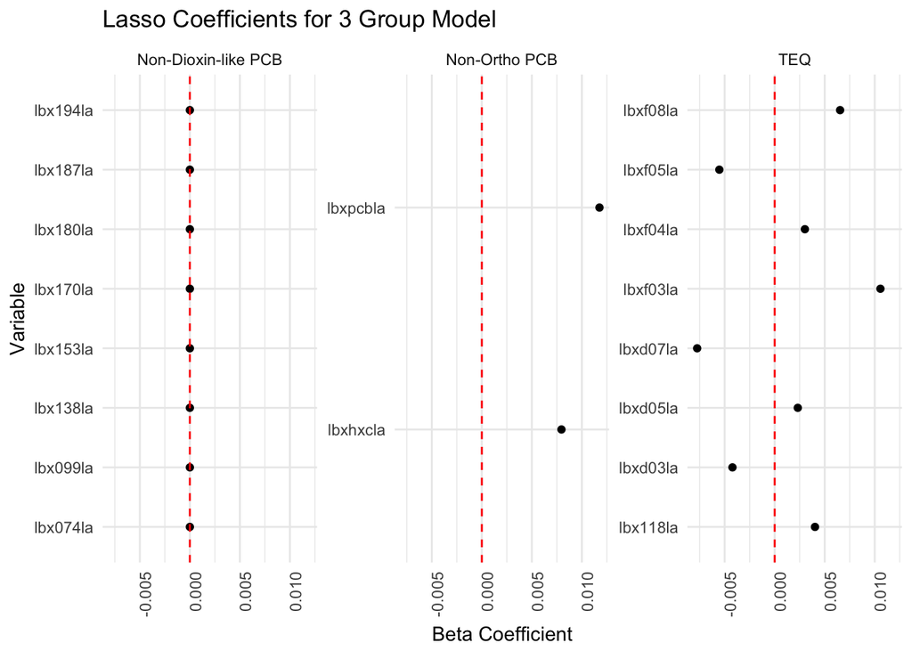

```r
#3 group model
lasso_beta_3 <- as_tibble(fit_lasso_3$beta, rownames = "variable") %>%
  rename(beta = `0.0058`) %>%
  filter(variable != "(Intercept)") %>%
  mutate(group3 = group3,
         group4 = group4,
         method = "Grouped Lasso")

#Filter out covariates
lasso_beta_3 %>%
  filter(group3 %in% c("TEQ", "Non-Dioxin-like PCB", "Non-Ortho PCB")) %>%
  ggplot(aes(x = variable, y = round(beta, 5))) +
  geom_point() + theme_minimal() + geom_hline(yintercept = 0, color = "red", linetype = "dashed") +
  facet_wrap(~ group3, scales = "free_y") +
  theme(axis.text.x = element_text(angle = 90, hjust = 1)) + coord_flip() +
  labs(title = "Lasso Coefficients for 3 Group Model", y = "Beta Coefficient", x = "Variable")
```

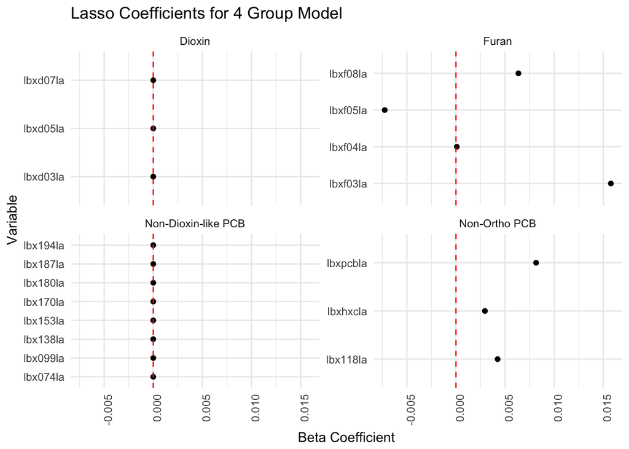

```r
#4 group model
lasso_beta_4 <- as_tibble(fit_lasso_4$beta, rownames = "variable") %>%
  rename(beta = `0.0059`) %>%
  filter(variable != "(Intercept)") %>%
  mutate(group3 = group3,
         group4 = group4)

#Filter out covariates
lasso_beta_4 %>%
  filter(group4 %in% c("Dioxin", "Furan", "Non-Dioxin-like PCB", "Non-Ortho PCB")) %>%
  ggplot(aes(x = variable, y = round(beta, 5))) +
  geom_point() + theme_minimal() + geom_hline(yintercept = 0, color = "red", linetype = "dashed") +
  facet_wrap(~ group4, scales = "free_y") +
  theme(axis.text.x = element_text(angle = 90, hjust = 1)) + coord_flip() +
  labs(title = "Lasso Coefficients for 4 Group Model", y = "Beta Coefficient", x = "Variable")
```

# MCP w/ CV

We repeat the previous analyses, substituting the MCP penalty for the lasso.

```r
#3 group model

#CV to choose the best tuning parameter lambda (ten-fold default)
cv_mcp_3 <- cv.grpreg(x, y, group3,
                      penalty = "grMCP",
                      seed = 1988)

#Find the lambda that results in the smallest CV error
best_mcp_3 <- cv_mcp_3$lambda.min

#Fit model with cross-validated lambda
fit_mcp_3 <- grpreg(x, y, group3, penalty = "grMCP", lambda = best_mcp_3)

#Look at coefficients from model with best lambda
fit_mcp_3$beta
```

```
##                      0.0123
## (Intercept)  0.168113979248
## lbx074la     0.000000000000
## lbx099la     0.000000000000
## lbx118la     0.000000000000
## lbx138la     0.000000000000
## lbx153la     0.000000000000
## lbx170la     0.000000000000
## lbx180la     0.000000000000
## lbx187la     0.000000000000
## lbxd03la     0.000000000000
## lbxd05la     0.000000000000
## lbxd07la     0.000000000000
## lbxf03la     0.000000000000
## lbxf04la     0.000000000000
## lbxf05la     0.000000000000
## lbxf08la     0.000000000000
## lbxpcbla     0.009675409361
## lbxhxcla     0.005532614496
## lbx194la     0.000000000000
## lbxwbcsi    -0.006585352805
## lbxlypct    -0.000943345379
## lbxmopct    -0.005720846470
## lbxnepct    -0.000184037111
## lbxeopct    -0.000151195001
## lbxbapct     0.019023025189
## bmi_cat32   -0.004784750479
## bmi_cat33   -0.018368306398
## edu_cat2     0.019844518474
## edu_cat3     0.036634714555
## edu_cat4     0.016512004857
## race_cat2   -0.034578282039
## race_cat3    0.008902188420
## race_cat4   -0.036006548089
## male1       -0.039081709910
## ln_lbxcot    0.003072697975
## age_cent    -0.005956663168
## age_sq      -0.000007546895
```

```r
#4 group model
#CV to choose the best tuning parameter lambda (ten-fold default)
cv_mcp_4 <- cv.grpreg(x, y, group4, penalty = "grMCP", seed = 1988)

#Find the lambda that results in the smallest CV error
best_mcp_4 <- cv_mcp_4$lambda.min

#Fit model with cross-validated lambda
fit_mcp_4 <- grpreg(x, y, group4, penalty = "grMCP", lambda = best_mcp_4)

#Look at coefficients from model with best lambda
fit_mcp_4$beta
```

```
##                     0.0085
## (Intercept)  0.25154631737
## lbx074la     0.00000000000
## lbx099la     0.00000000000
## lbx118la     0.01266696892
## lbx138la     0.00000000000
## lbx153la     0.00000000000
## lbx170la     0.00000000000
## lbx180la     0.00000000000
## lbx187la     0.00000000000
## lbxd03la     0.00000000000
## lbxd05la     0.00000000000
## lbxd07la     0.00000000000
## lbxf03la     0.00000000000
## lbxf04la     0.00000000000
## lbxf05la     0.00000000000
## lbxf08la     0.00000000000
## lbxpcbla     0.01422003869
## lbxhxcla     0.01641310572
## lbx194la     0.00000000000
## lbxwbcsi    -0.00627217288
## lbxlypct    -0.00340936089
## lbxmopct    -0.00831943965
## lbxnepct    -0.00257700963
## lbxeopct    -0.00261701403
## lbxbapct     0.01565744189
## bmi_cat32   -0.00270268821
## bmi_cat33   -0.01896934175
## edu_cat2     0.01714720985
## edu_cat3     0.03351945513
## edu_cat4     0.01364965462
## race_cat2   -0.02705074266
## race_cat3    0.00500505492
## race_cat4   -0.03513298570
## male1       -0.03702438102
## ln_lbxcot    0.00349986338
## age_cent    -0.00680441463
## age_sq      -0.00000773211
```

## Data Visualization

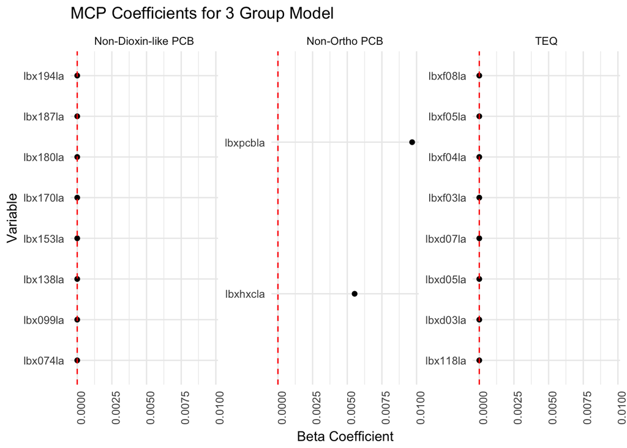

```r
#3 group model
mcp_beta_3 <- as_tibble(fit_mcp_3$beta, rownames = "variable") %>%
  rename(beta = `0.0123`) %>%
  filter(variable != "(Intercept)") %>%
  mutate(group3 = group3,
         group4 = group4,
         method = "MCP")

#Filter out covariates
mcp_beta_3 %>%
  filter(group3 %in% c("TEQ", "Non-Dioxin-like PCB", "Non-Ortho PCB")) %>%
  ggplot(aes(x = variable, y = round(beta, 5))) +
  geom_point() + theme_minimal() + geom_hline(yintercept = 0, color = "red", linetype = "dashed") +
  facet_wrap(~ group3, scales = "free_y") +
  theme(axis.text.x = element_text(angle = 90, hjust = 1)) + coord_flip() +
  labs(title = "MCP Coefficients for 3 Group Model", y = "Beta Coefficient", x = "Variable")
```

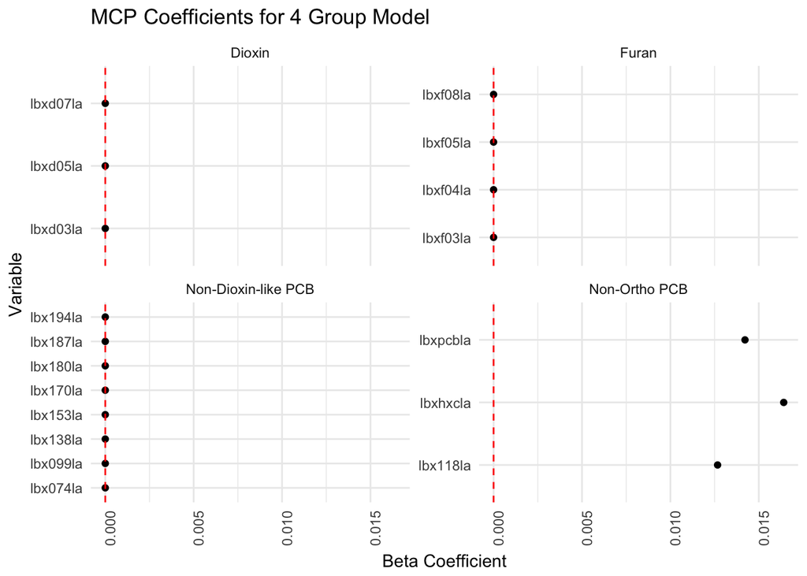

```r
#4 group model
mcp_beta_4 <- as_tibble(fit_mcp_4$beta, rownames = "variable") %>%
  rename(beta = `0.0085`) %>%
  filter(variable != "(Intercept)") %>%
  mutate(group3 = group3,
         group4 = group4)

#Filter out covariates
mcp_beta_4 %>%
  filter(group4 %in% c("Dioxin", "Furan", "Non-Dioxin-like PCB", "Non-Ortho PCB")) %>%
  ggplot(aes(x = variable, y = round(beta, 5))) +
  geom_point() + theme_minimal() + geom_hline(yintercept = 0, color = "red", linetype = "dashed") +
  facet_wrap(~ group4, scales = "free_y") +
  theme(axis.text.x = element_text(angle = 90, hjust = 1)) + coord_flip() +
  labs(title = "MCP Coefficients for 4 Group Model", y = "Beta Coefficient", x = "Variable")
```

# SCAD w/ CV

```r
#3 group model

#CV to choose the best tuning parameter lambda (ten-fold default)
cv_scad_3 <- cv.grpreg(x, y, group3,
                       penalty = "grSCAD",
                       seed = 1988)

#Find the lambda that results in the smallest CV error
best_scad_3 <- cv_scad_3$lambda.min

#Fit model with cross-validated lambda
fit_scad_3 <- grpreg(x, y, group3, penalty = "grSCAD", lambda = best_scad_3)

#Look at coefficients from model with best lambda
fit_scad_3$beta
```

```
##                     0.0077
## (Intercept)  0.38457129943
## lbx074la     0.00000000000
## lbx099la     0.00000000000
## lbx118la     0.00010833452
## lbx138la     0.00000000000
## lbx153la     0.00000000000
## lbx170la     0.00000000000
## lbx180la     0.00000000000
## lbx187la     0.00000000000
## lbxd03la    -0.00015911438
## lbxd05la     0.00006624098
## lbxd07la    -0.00026034744
## lbxf03la     0.00036461200
## lbxf04la     0.00010997968
## lbxf05la    -0.00022234364
## lbxf08la     0.00022973355
## lbxpcbla     0.01700726506
## lbxhxcla     0.01485161902
## lbx194la     0.00000000000
## lbxwbcsi    -0.00636378938
## lbxlypct    -0.00365547238
## lbxmopct    -0.00842320321
## lbxnepct    -0.00280517116
## lbxeopct    -0.00284602912
## lbxbapct     0.01592572190
## bmi_cat32   -0.00314376714
## bmi_cat33   -0.01845934314
## edu_cat2     0.01788835648
## edu_cat3     0.03486743546
## edu_cat4     0.01477110000
## race_cat2   -0.02978830243
## race_cat3    0.00837055535
## race_cat4   -0.03477836931
## male1       -0.04009816368
## ln_lbxcot    0.00336033769
## age_cent    -0.00643943791
## age_sq      -0.00000647549
```

```r
#4 group model
#CV to choose the best tuning parameter lambda (ten-fold default)
cv_scad_4 <- cv.grpreg(x, y, group4, penalty = "grSCAD", seed = 1988)

#Find the lambda that results in the smallest CV error
best_scad_4 <- cv_scad_4$lambda.min

#Fit model with cross-validated lambda
fit_scad_4 <- grpreg(x, y, group4, penalty = "grSCAD", lambda = best_scad_4)

#Look at coefficients from model with best lambda
fit_scad_4$beta
```

```
##                       0.0071
## (Intercept)  0.1386165521822
## lbx074la     0.0000000000000
## lbx099la     0.0000000000000
## lbx118la     0.0029804879451
## lbx138la     0.0000000000000
## lbx153la     0.0000000000000
## lbx170la     0.0000000000000
## lbx180la     0.0000000000000
## lbx187la     0.0000000000000
## lbxd03la     0.0000000000000
## lbxd05la     0.0000000000000
## lbxd07la     0.0000000000000
## lbxf03la     0.0129187728817
## lbxf04la    -0.0000242336614
## lbxf05la    -0.0058375447169
## lbxf08la     0.0053993553118
## lbxpcbla     0.0067567047222
## lbxhxcla     0.0022612345280
## lbx194la     0.0000000000000
## lbxwbcsi    -0.0064136516277
## lbxlypct    -0.0009771300971
## lbxmopct    -0.0060453171281
## lbxnepct    -0.0001895617504
## lbxeopct     0.0000004184151
## lbxbapct     0.0186572533259
## bmi_cat32   -0.0049604268776
## bmi_cat33   -0.0173126358201
## edu_cat2     0.0207344830709
## edu_cat3     0.0374466332620
## edu_cat4     0.0165681906669
## race_cat2   -0.0333732724403
## race_cat3    0.0067357862573
## race_cat4   -0.0371118525323
## male1       -0.0374032312954
## ln_lbxcot    0.0030510480901
## age_cent    -0.0060783233556
## age_sq      -0.0000089849208
```

## Data Visualization

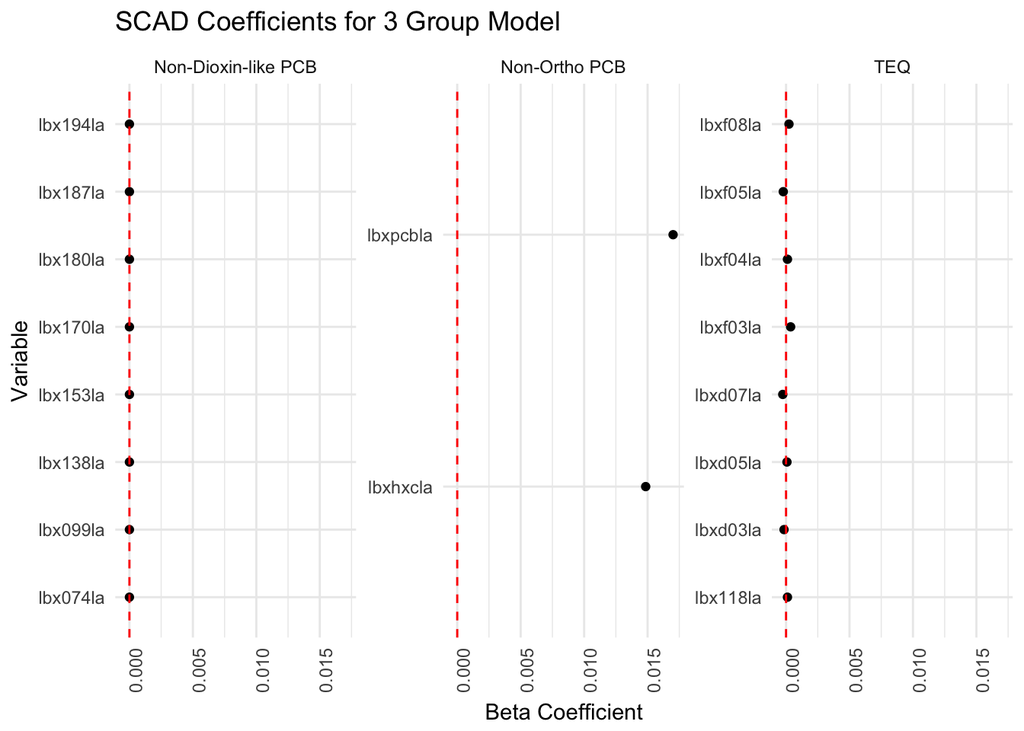

```r
#3 group model
scad_beta_3 <- as_tibble(fit_scad_3$beta, rownames = "variable") %>%
  rename(beta = `0.0077`) %>%
  filter(variable != "(Intercept)") %>%
  mutate(group3 = group3,
         group4 = group4,
         method = "SCAD")

#Filter out covariates
scad_beta_3 %>%
  filter(group3 %in% c("TEQ", "Non-Dioxin-like PCB", "Non-Ortho PCB")) %>%
  ggplot(aes(x = variable, y = round(beta, 5))) +
  geom_point() + theme_minimal() +
  geom_hline(yintercept = 0, color = "red", linetype = "dashed") +
  facet_wrap(~ group3, scales = "free_y") +
  theme(axis.text.x = element_text(angle = 90, hjust = 1)) + coord_flip() +
  labs(title = "SCAD Coefficients for 3 Group Model", y = "Beta Coefficient", x = "Variable")
```

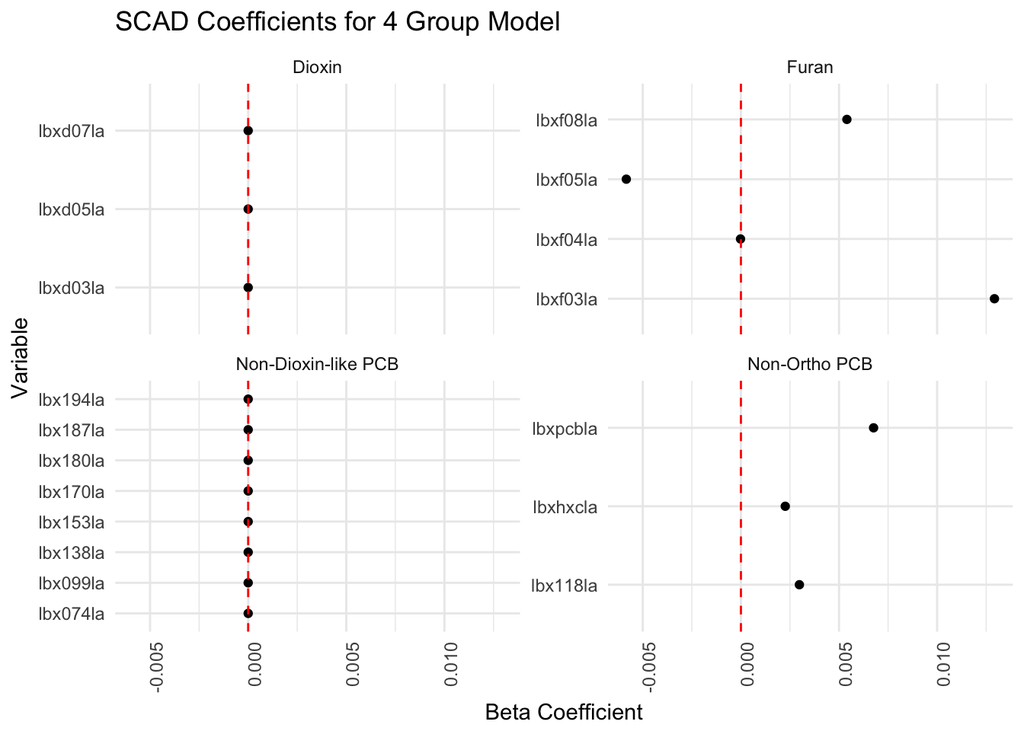

```r
#4 group model
scad_beta_4 <- as_tibble(fit_scad_4$beta, rownames = "variable") %>%
  rename(beta = `0.0071`) %>%
  filter(variable != "(Intercept)") %>%
  mutate(group3 = group3,
         group4 = group4)

#Filter out covariates
scad_beta_4 %>%
  filter(group4 %in% c("Dioxin", "Furan", "Non-Dioxin-like PCB", "Non-Ortho PCB")) %>%
  ggplot(aes(x = variable, y = round(beta, 5))) +
  geom_point() + theme_minimal() +
  geom_hline(yintercept = 0, color = "red", linetype = "dashed") +
  facet_wrap(~ group4, scales = "free_y") +
  theme(axis.text.x = element_text(angle = 90, hjust = 1)) + coord_flip() +
  labs(title = "SCAD Coefficients for 4 Group Model", y = "Beta Coefficient", x = "Variable")
```

```r
grouped <- rbind(lasso_beta_3, mcp_beta_3, scad_beta_3) %>%
  dplyr::select(-group3, -group4)

write_csv(grouped, "grouped_betas.csv")
```

## OLS from MCP Results

Lastly, we compare the results for MCP (with four groups) with the results from the corresponding OLS fit.

```r
mcp_beta =
  mcp_beta_4 %>%
  filter(beta != 0) %>%
  dplyr::select(term = variable, mcp = beta)

lm_from_mcp <- lm(log_telomean ~ lbx118la + lbxpcbla +  lbxhxcla +
     lbxwbcsi + lbxlypct + lbxmopct + lbxnepct + lbxeopct + lbxbapct +
     bmi_cat3 + edu_cat + race_cat + male, data = data_lasso)

ols_beta =
  lm_from_mcp %>%
  broom::tidy() %>%
  dplyr::select(term, ols = estimate)

ols_v_gmcp = left_join(mcp_beta, ols_beta)
ols_v_gmcp
```

```
## # A tibble: 21 x 3
##    term           mcp      ols
##    <chr>        <dbl>    <dbl>
##  1 lbx118la   0.0127  -0.0378
##  2 lbxpcbla   0.0142   0.0256
##  3 lbxhxcla   0.0164  -0.0560
##  4 lbxwbcsi  -0.00627 -0.00130
##  5 lbxlypct  -0.00341 -0.00396
##  6 lbxmopct  -0.00832 -0.0119
##  7 lbxnepct  -0.00258 -0.00411
##  8 lbxeopct  -0.00262 -0.00579
##  9 lbxbapct   0.0157   0.0106
## 10 bmi_cat32 -0.00270 -0.0359
## # ... with 11 more rows
```

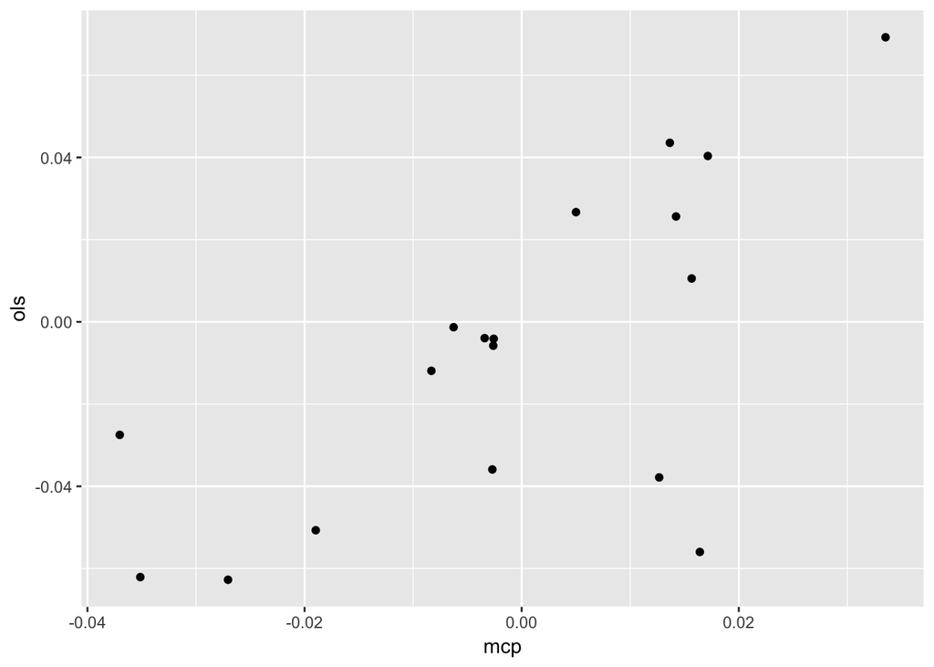

```r
ggplot(ols_v_gmcp, aes(x = mcp, y = ols)) + geom_point()
```